# Внешний курс 2 блок

Защита ПК телефона

Абронина Алиса Кирилловна

1132246717@rudn.ru

Российский университет дружбы народов

2026-05-15

# Информация

## Докладчик

- Абронина Алиса Кирилловна
- НКАбд-01-24
- Российский университет дружбы народов им. П. Лумумбы
- 1132246717@rudn.ru
- https://github.com/akabronina

# Цель работы

Пройти второй блок курса

# Выполнение второго блока внешнего курса

Совеременные системы шифрования диска умеют шифровать даже загрузочную область

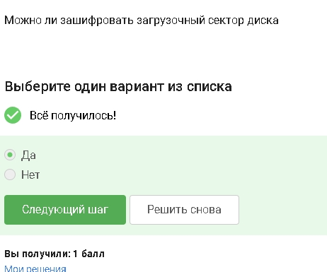

Используется один и тот же ключ для шифрования и расшифровки - это бычтрее для больших объемов данных

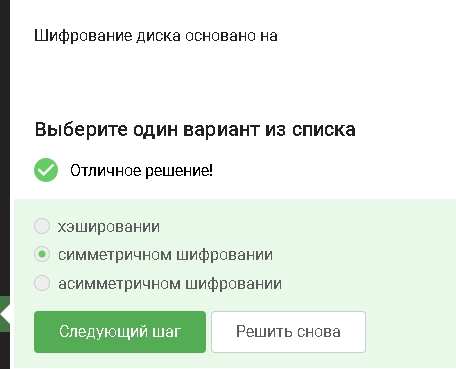

Wireshark анализирует трафик Disk Utility не является основной системой шифрования в этом констексте

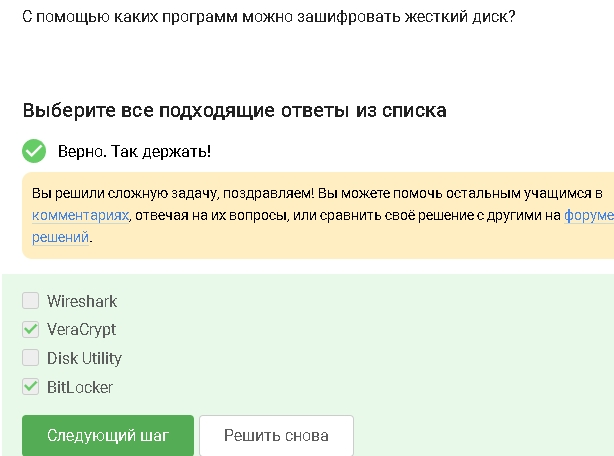

Длинный случайный с разными типами символов его сложно подобрать

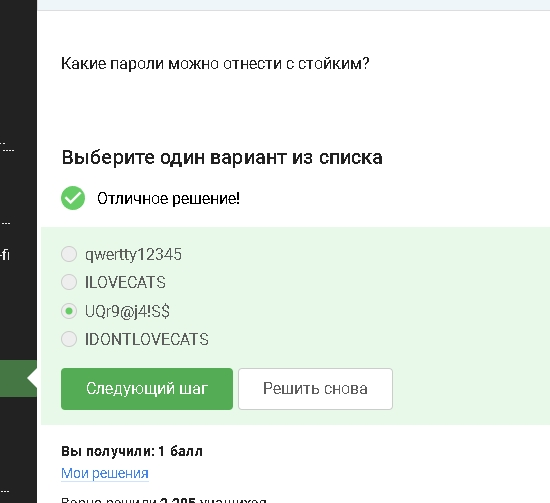

Они шифруют данные и помогают хранить слодные уникальные пароли

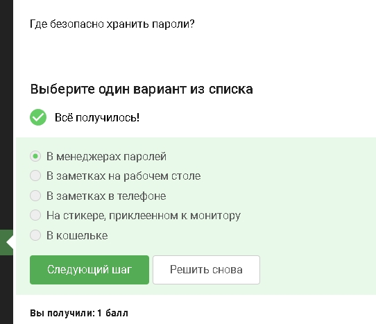

CAPTCHA проверяет что пользователь человек а не бот

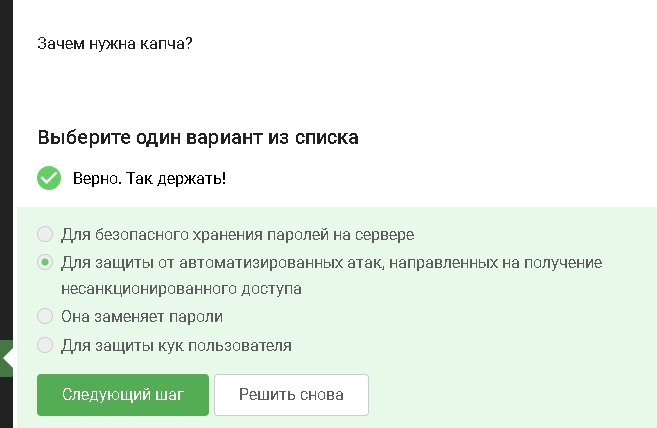

На сервере хранится не пароль а его кэш

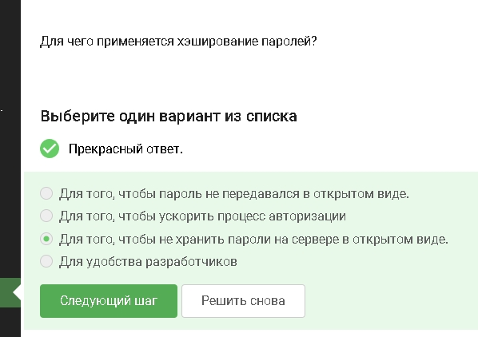

Соль усложняет массовый перебор и использование готовых таблиц, но не делает пароль неуязвивым, если слабый

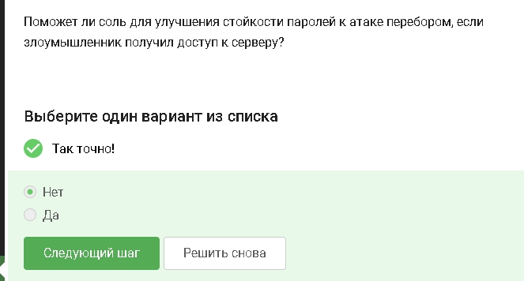

Разные пароли - утечка одного не ломает остальные аккаунты. Периодическая смена - снижает время использования украденного пароля. Слодные длинные пароли - тяжелее подобрать. Капча - мешает автоматическому перебору

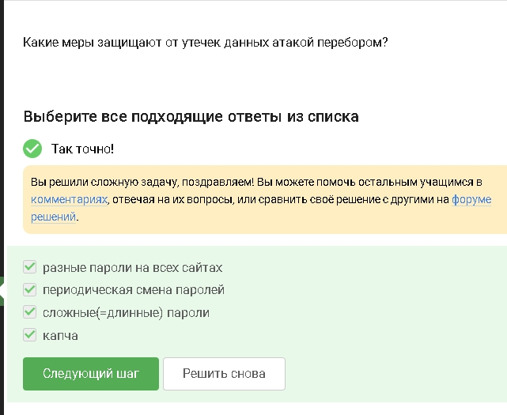

В себре настоящий домен не wix.ru в яндексе настоящий ucoz.ru

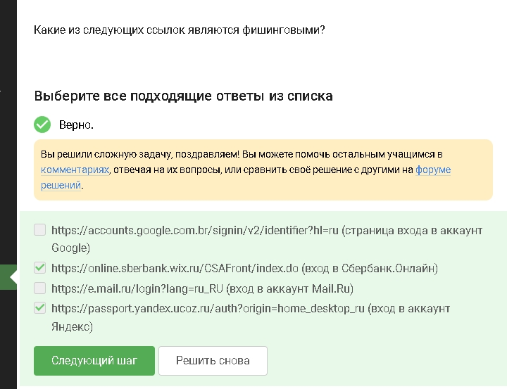

Адрес отправителя можно подделать или аккаунт знакомого модет быть взломан

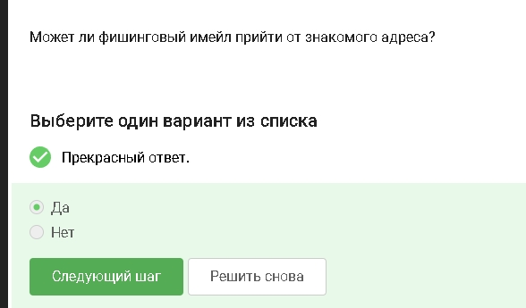

Злоумышленник делает вид, что письмо от другого человека/компании

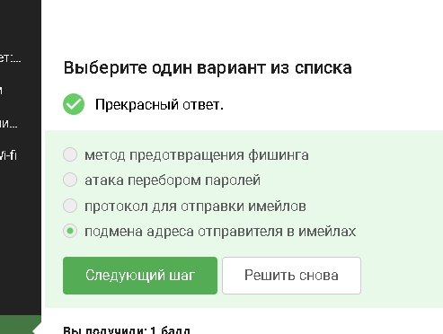

Пользователь думает, что запускает полезное ПО

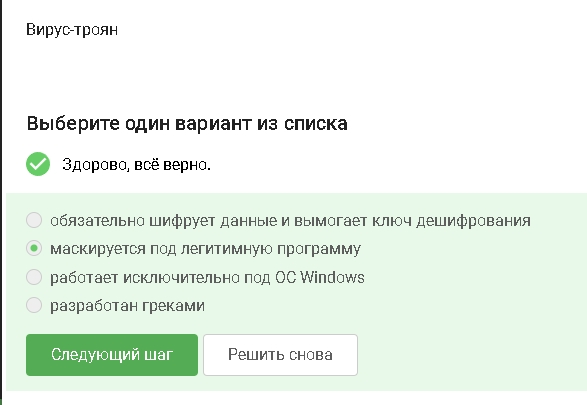

Сигнал создает ключи и запускает механизм защищенного обмена при начале общения

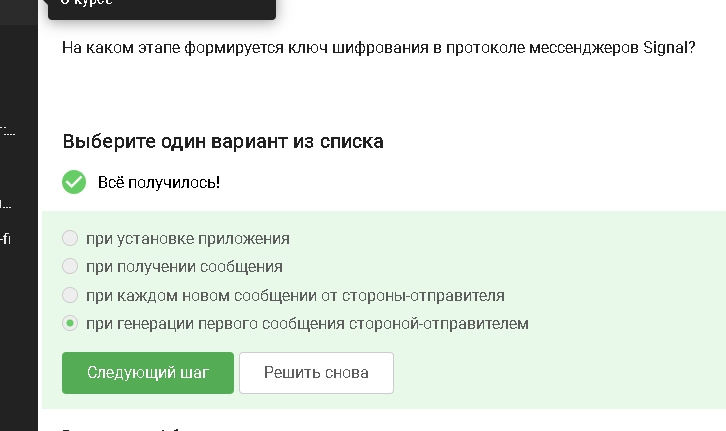

Сервер передает данные, но не может прочитать содержимое сообщенийй

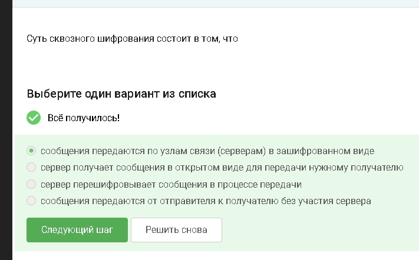

# Выводы

Прошла второй блок внешнего курса.